# Replication code for Cardoso & Dahis (2024)

Author

Diego S. Cardoso and Ricardo Dahis

Published

March 25, 2024

This Quarto document contains the replication code for the illustrations in the paper titled “Calculating the economic value of non-marginal mortality risk reductions”, forthcoming in the Economics Letters. DOI: https://doi.org/10.1016/j.econlet.2024.111673

Suggested citation:

> Cardoso, D., Dahis. R. Calculating the economic value of non-marginal mortality risk reductions. Economics Letters (2004), DOI 10.1016/j.econlet.2024.111673.

This package does not include the mortality data maintained by the United Nations. These data is publicly available from [United Nations World Population Prospects 2022 website](https://population.un.org/wpp/Download/Standard/CSV/).

The results displayed in the paper were obtained using this code running on R version 4.3.1. It has the following dependencies:

- `data.table` version 1.14.8: for data manipulation
- `xtable` version 1.8-4: for formatting exporting results tables
- `ggplot2` version 3.4.3: for generating graphs
- `latex2exp` version 0.9.6: for inserting mathematical symbols into graphs

## 1. Setup

```r
knitr::opts_knit$set(root.dir = rprojroot::find_rstudio_root_file())

# Data manipulation packages
library(data.table)

# Table exporting package
library(xtable)

# Plotting packages
library(latex2exp)
library(ggplot2)

# Path to folder where data files are
DATA_FOLDER <- "." # <---- REPLACE HERE

# Path to folder where tables and graphs should be saved
OUTPUT_FOLDER <- "." # <---- REPLACE HERE
```

### 1.1 Environment parameters

```r
SAVETAB <- T # If false, running the code will not export any tables
SAVEFIG <- T # If false, running the code will not export any graphs
```

### 1.2 Model parameters

- VSL-to-income ratio: $\hat{v} = 160$
- Reference-age: $\hat{a} = 40$
- Discount rate: 3%
- Age groups considered: 20, 50, and 80

```r
V_HAT <- 160
A_HAT <- 40
BETA <- 1/(1+0.03)
AGES <- c(20, 50, 80)
```

Define a base year for the illustration and a previous year for comparison of mortality changes over time

```r
BASE_YEAR <- 2015
PRE_YEAR <- 1990
```

### 1.3 Data

Load complete (annual) life tables from the [United Nations World Population Prospects 2022](https://population.un.org/wpp/Download/Standard/CSV/).

```r
life_table <- fread(file.path(DATA_FOLDER, "WPP2022_Life_Table_Complete_Medium_Both_1950-2021.csv"))
```

For this illustration, we are going to look at the US in the base year and compare with mortality rates in an earlier year to gauge the magnitude of differences.

```r
life_table <- life_table[Time %in% c(PRE_YEAR, BASE_YEAR) & ISO3_code == "USA"]
```

Rename columns and keep only the ones needed for this illustration

```r
life_table <- life_table[,.(
  year = Time,
  age = AgeGrpStart, # Age group a
  s_a = Sx # Annual survival probability
)]
```

## 2. Calculations

### 2.1 Discounted life expectancy

We assume the annual survival probability for ages above 100 is held constant. Then, for the final age group of 100, the discounted life expectancy is given by

$$l_{100} = \sum^\infty_{t=0}\beta^t s_{100}^t = \frac{1}{1-\beta s_{100}}$$

```r
life_table[age == 100, l_a:=1/(1-BETA*s_a)]
```

Life expectancy for earlier ages can be easily calculated using the recursive relation:
$$l_{a} = s_a + \beta s_a\sum^\infty_{t=0}\beta^t S_{a+1, t}^t = s_a (1 + \beta l_{a+1})$$

```r
setorder(life_table, year, -age)

# We cannot vectorize this because each age depends on a write-read-write cycle, so we need to iterate recursively
for (a in seq(99, 0)) {
  life_table[, l_a:=ifelse(age == a & age != 100, s_a * (1 + BETA * shift(l_a, 1)), l_a),
             by=.(year)]
}
```

```r
S_A_HAT <- life_table[year == BASE_YEAR & age == A_HAT, s_a]
L_A_HAT <- life_table[year == BASE_YEAR & age == A_HAT, l_a]
GAMMA_HAT <- V_HAT/L_A_HAT*S_A_HAT
```

To make sense of the magnitude, these are the differences across ages.

```r
life_table[age %in% AGES,
           .(s_a, l_a),
           by=.(age, year)]
```

```
   age year       s_a       l_a
1:  80 1990 0.9400301  6.984786
2:  50 1990 0.9954383 18.816791
3:  20 1990 0.9989518 27.114307
4:  80 2015 0.9548723  7.809441
5:  50 2015 0.9960973 19.980828
6:  20 2015 0.9992553 27.717935
```

To gauge the SMUs for the illustration, we compare survival probabilities between the base and previous years in SMUs (10^-4)

```r
life_table[age %in% AGES,
           .(SMU_change = (max(s_a) - min(s_a))*10^4,
             la_change = (max(l_a) - min(l_a))),
            by=.(age)]
```

```
   age SMU_change la_change
1:  80   148.4219 0.8246550
2:  50     6.5897 1.1640371
3:  20     3.0347 0.6036287
```

### 2.2 Valuation

Our illustration focuses on 3 age groups: 20, 50, and 80. We select those values in a separate table for further calculations.

```r
vsly_illustration_data <- life_table[age %in% AGES & year == BASE_YEAR]
```

Define a grid of DLE changes up to 1

```r
L_STEP <- 0.01
delta_l_grid <- seq(0, 1, L_STEP)
```

Perform a cartesian product with the grid

```r
vsly_illustration_data[,VAR:=1] # Auxiliary variable just for the product
vsly_illustration_data <- merge(vsly_illustration_data, data.table(delta_l=delta_l_grid, VAR=1), by="VAR", allow.cartesian = T)
vsly_illustration_data[,VAR:=NULL]
```

Calculate $\tilde{l}$

```r
vsly_illustration_data[, l_a_tilde:=l_a + delta_l]
```

We need to assume a $tilde{s}$. In this case, we will assume it increases in the same proportion as $l$, so

$$\tilde{s}_a = s_a \frac{\tilde{l}_a}{l_a}$$

So that $\tilde{l}_a/\tilde{s}_a = l_a / s_a$

```r
vsly_illustration_data[, s_a_tilde:=s_a * l_a_tilde/l_a]
```

The following function calculates $b_a$ following the formula derived in the paper.

```r
calculate_b_a <- function(l_a, l_a_tilde, s_a_tilde, gamma_hat, s_a_hat, rho) {
  if (rho == 0) { # Linear case
    b <- (l_a_tilde - l_a)*gamma_hat
  }
  else {
    if (rho == 1) { # Log utility
      b <- l_a_tilde/s_a_tilde * (1 - exp(-(l_a_tilde - l_a)/l_a_tilde*gamma_hat*s_a_hat))
    } else { # CRRA with rho != 1
      b <- l_a_tilde/s_a_tilde * (1 - ( 1 - (1-rho)*(l_a_tilde - l_a)/l_a_tilde*gamma_hat*s_a_hat)^(1/(1-rho)))
    }
  }
}
```

Apply functions to calculate $b_a$ for the linear, log, and $\rho=2$ cases.

```r
vsly_illustration_data[, b_linear:=calculate_b_a(l_a, l_a_tilde, s_a_tilde, GAMMA_HAT, s_a, rho = 0)]
vsly_illustration_data[, b_log:=   calculate_b_a(l_a, l_a_tilde, s_a_tilde, GAMMA_HAT, s_a, rho = 1)]
vsly_illustration_data[, b_crra:=  calculate_b_a(l_a, l_a_tilde, s_a_tilde, GAMMA_HAT, s_a, rho = 2)]
```

For plotting, calculate the marginal value

```r
vsly_illustration_data[, mg_b_linear:= (b_linear-shift(b_linear, 1))/L_STEP, by=age]
vsly_illustration_data[, mg_b_log:= (b_log-shift(b_log, 1))/L_STEP, by=age]
vsly_illustration_data[, mg_b_crra:= (b_crra-shift(b_crra, 1))/L_STEP, by=age]
```

Manually set initial marginal values

```r
vsly_illustration_data[delta_l == 0, mg_b_linear:= GAMMA_HAT]
vsly_illustration_data[delta_l == 0, mg_b_log:= GAMMA_HAT]
vsly_illustration_data[delta_l == 0, mg_b_crra:= GAMMA_HAT]
```

Make marginal changes relative to initial for plotting

```r
vsly_illustration_data[, rel_mg_b_linear := mg_b_linear/GAMMA_HAT]
vsly_illustration_data[, rel_mg_b_log := mg_b_log/GAMMA_HAT]
vsly_illustration_data[, rel_mg_b_crra := mg_b_crra/GAMMA_HAT]
```

Also calculate marginal VSL

```r
vsly_illustration_data[, mg_v_linear := mg_b_linear*l_a/s_a]
vsly_illustration_data[, mg_v_log := mg_b_log*l_a/s_a]
vsly_illustration_data[, mg_v_crra := mg_b_crra*l_a/s_a]
```

## 3. Output

### 3.1 Tables

```r
results <- vsly_illustration_data[delta_l == 1,
                                  .(l_a,
                                    inc = l_a_tilde/l_a - 1,
                                    b_linear,
                                    b_log,
                                    b_crra,
                                    initial_VSLY = mg_b_linear,
                                    mg_vsly_linear = mg_b_linear,
                                    mg_vsly_log = mg_b_log,
                                    mg_vsly_crr = mg_b_crra
                                  ), by=.(age)]

setorder(results, age)
results
```

```
   age       l_a        inc b_linear    b_log   b_crra initial_VSLY
1:  20 27.717935 0.03607772  6.88771 5.911253 5.362650      6.88771
2:  50 19.980828 0.05004798  6.88771 5.594880 4.943030      6.88771
3:  80  7.809441 0.12805015  6.88771 4.301995 3.495907      6.88771
   mg_vsly_linear mg_vsly_log mg_vsly_crr
1:        6.88771    5.056621    4.184530
2:        6.88771    4.513610    3.557456
3:        6.88771    2.577025    1.783154
```

Format table for exporting.

```r
# Transpose
results_table <- as.data.frame(transpose(results[,2:10]))

# Add column with variable names
latex_colnames <- c(
  "Discounted Life Expectancy (DLE) [$l_a$]",
  "Proportional DLE increase [$1/l_a$]",
  "Value, linear [$b^{linear}(l_a, l_a + 1)$]",
  "Value, CCV $\\rho = 1$ [$b^{log}(l_a, l_a + 1)$]",
  "Value, CCV $\\rho = 2$ [$b^{crra}(l_a, l_a + 1)$]",
  "Initial VSLY",
  "Marginal VSLY, linear",
  "Marginal VSLY, CCV $\\rho = 1$",
  "Marginal VSLY, CCV $\\rho = 2$")

results_table <- cbind(latex_colnames, results_table)

# Define header
tab_header <- list()
tab_header$pos <- list()
tab_header$pos[[1]] <- 0
tab_header$command <- c(" & \\multicolumn{3}{c}{Age} \\\\ \\cline{2-4}
                        & 20 & 50 & 80 \\\\
                        ")
```

```r
if(SAVETAB) {
  print(xtable(results_table),
        include.rownames = FALSE,
        include.colnames = FALSE,
        floating = FALSE,
        sanitize.text.function = I,
        add.to.row = tab_header,
        hline.after = c(-1, 0, 9),
        digits = 2,
        file=file.path(OUTPUT_FOLDER, "illustration_table.tex"))
}
```

### 3.2 Plots

Format age labels

```r
vsly_illustration_data[, age_label:=paste0("Age ", age)]
```

Results per age group

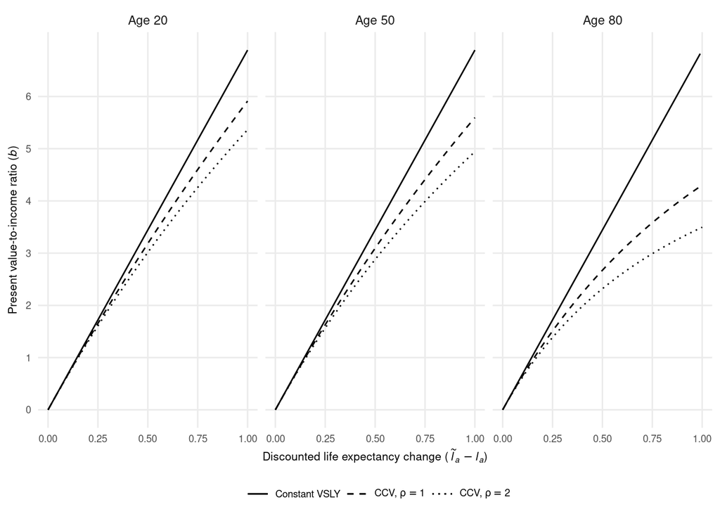

```r
ggplot(vsly_illustration_data, aes(x=delta_l)) +
  geom_line(aes(y=b_linear, linetype="0_linear")) +
  geom_line(aes(y=b_log, linetype="1_log")) +
  geom_line(aes(y=b_crra, linetype="2_crra")) +
  labs(x=TeX("Discounted life expectancy change ($\\textit{\\tilde{l}_a-l_a}$)"),
       y=TeX("Present value-to-income ratio ($\\textit{b}$)")) +
  scale_y_continuous(limits=c(0,GAMMA_HAT), breaks=seq(0, 6)) +
  scale_x_continuous(limits=c(0,1), breaks=seq(0, 1, 0.25)) +
  scale_linetype_manual(name="",
                 values=c("0_linear"="solid",
                          "1_log"="dashed",
                          "2_crra"="dotted"),
                 labels=c("Constant VSLY", TeX("CCV, $\\rho=1"), TeX("CCV, $\\rho=2"))) +
  facet_wrap(~age_label, scales="fixed") +
  theme_minimal() +
  theme(legend.position = "bottom",
        legend.box = "vertical",
        legend.title = element_text(size = 7),
        legend.text = element_text(size = 7),
        panel.grid.minor.y = element_blank(),
        panel.grid.minor.x = element_blank(),
        axis.text = element_text (size = 7),
        axis.title.x = element_text(size = 8),
        axis.title.y = element_text(size = 8),
        legend.margin = margin(b=0, unit = "cm")
        )
```

```r
if(SAVEFIG) ggsave(file.path(OUTPUT_FOLDER, "VSLY_NPV_by_method.pdf"),
                 width = 5.5, height = 3.2)
```

Marginal to initial VSLY ratios

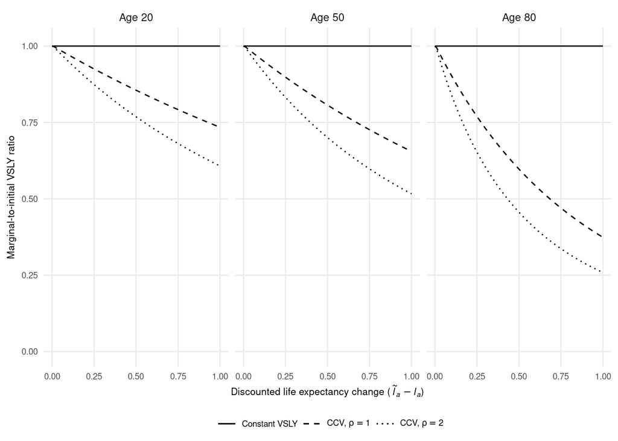

```r
ggplot(vsly_illustration_data, aes(x=delta_l)) +
  geom_line(aes(y=rel_mg_b_linear, linetype="0_linear")) +
  geom_line(aes(y=rel_mg_b_log, linetype="1_log")) +
  geom_line(aes(y=rel_mg_b_crra, linetype="2_crra")) +
  labs(x=TeX("Discounted life expectancy change ($\\textit{\\tilde{l}_a-l_a}$)"),
       y=TeX("Marginal-to-initial VSLY ratio")) +
  scale_y_continuous(limits=c(0,1.01), breaks=seq(0, 1.0, 0.25)) +
  scale_x_continuous(limits=c(0,1), breaks=seq(0, 1, 0.25)) +
  scale_linetype_manual(name="",
                 values=c("0_linear"="solid",
                          "1_log"="dashed",
                          "2_crra"="dotted"),
                 labels=c("Constant VSLY", TeX("CCV, $\\rho=1"), TeX("CCV, $\\rho=2"))) +
  facet_wrap(~age_label, scales="fixed") +
  theme_minimal() +
  theme(legend.position = "bottom",
        legend.box = "vertical",
        legend.title = element_text(size = 7),
        legend.text = element_text(size = 7),
        panel.grid.minor.y = element_blank(),
        panel.grid.minor.x = element_blank(),
        axis.text = element_text (size = 7),
        axis.title.x = element_text(size = 8),
        axis.title.y = element_text(size = 8),
        legend.margin = margin(b=0, unit = "cm")
        )
```

```r
if(SAVEFIG) ggsave(file.path(OUTPUT_FOLDER, "Mg_VSLY_NPV_by_method.pdf"),
                 width = 5.5, height = 3.2)
```

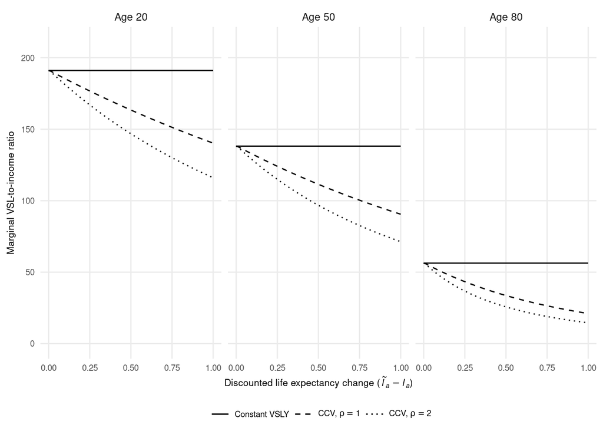

```r
ggplot(vsly_illustration_data, aes(x=delta_l)) +
  geom_line(aes(y=mg_v_linear, linetype="0_linear")) +
  geom_line(aes(y=mg_v_log, linetype="1_log")) +
  geom_line(aes(y=mg_v_crra, linetype="2_crra")) +
  labs(x=TeX("Discounted life expectancy change ($\\textit{\\tilde{l}_a-l_a}$)"),
       y=TeX("Marginal VSL-to-income ratio")) +
  scale_y_continuous(limits=c(0,211), breaks=seq(0, 200, 50)) +
  scale_x_continuous(limits=c(0,1), breaks=seq(0, 1, 0.25)) +
  scale_linetype_manual(name="",
                 values=c("0_linear"="solid",
                          "1_log"="dashed",
                          "2_crra"="dotted"),
                 labels=c("Constant VSLY", TeX("CCV, $\\rho=1"), TeX("CCV, $\\rho=2"))) +
  facet_wrap(~age_label, scales="fixed") +
  theme_minimal() +
  theme(legend.position = "bottom",
        legend.box = "vertical",
        legend.title = element_text(size = 7),
        legend.text = element_text(size = 7),
        panel.grid.minor.y = element_blank(),
        panel.grid.minor.x = element_blank(),
        axis.text = element_text (size = 7),
        axis.title.x = element_text(size = 8),
        axis.title.y = element_text(size = 8),
        legend.margin = margin(b=0, unit = "cm")
        )
```

```r
if(SAVEFIG) ggsave(file.path(OUTPUT_FOLDER, "Mg_VSL_NPV_by_method.pdf"),
                 width = 5.5, height = 3.2)
```